# Clase 4. Categorías, porcentajes y gráficos de barra.

#### **1. Cargar paquetes.**

Trabajaremos principalmente con `ggplot2` (incluido en `tidyverse`) y `readxl` para importar los datos.

```r
library(tidyverse)
library(readxl)
```

#### **2. Importar datos.**

En esta clase trabajaremos con dos bases de datos: `ceramica.xlsx` y `Diametro ceramica.xlsx`. Puedes encontrarlas en el repositorio del curso.

```r
ceramica <- read_excel("~/Desktop/work/0_Cuantitativa_2026/ANT305Q-2026/Clases/Clase4/ceramica.xlsx")
ceramica
```

```
## # A tibble: 2 × 4
##   Categoria Costa Valle Cordillera
##   <chr>     <dbl> <dbl>      <dbl>
## 1 Modelada     31    44         25
## 2 Incisa       29    22         12
```

```r
diametro_ceramica <- read_excel("~/Desktop/work/0_Cuantitativa_2026/ANT305Q-2026/Clases/Clase4/Diametro ceramica.xlsx")
diametro_ceramica
```

```
## # A tibble: 63 × 2
##    Zona  Diametro
##    <chr>    <dbl>
##  1 Costa      7.5
##  2 Costa      7.3
##  3 Costa     11.5
##  4 Costa      7.5
##  5 Costa      6.6
##  6 Costa      4.2
##  7 Costa      4
##  8 Costa      6
##  9 Costa      7.7
## 10 Costa      9
## # ℹ 53 more rows
```

#### **3. Calcular porcentajes de columna.**

Para calcular qué porcentaje representa cada fila dentro de su columna usamos la función `prop.table()`, que calcula proporciones, y luego multiplicamos por 100 para obtener porcentajes.

Primero transformamos nuestra tabla a un `data.frame`, ya que vamos a agregar columnas nuevas con los porcentajes calculados.

```r
# Transformamos a data frame
data1 <- data.frame(ceramica)

# Calculamos el porcentaje de columna para cada zona geográfica
data1$porcentCosta     <- prop.table(data1$Costa) * 100
data1$porcentInterior  <- prop.table(data1$Valle) * 100
data1$porcentAltiplano <- prop.table(data1$Cordillera) * 100

# Revisamos el resultado: data1 debe incluir las nuevas columnas con porcentajes
data1
```

```
##   Categoria Costa Valle Cordillera porcentCosta porcentInterior
## 1  Modelada    31    44         25     51.66667        66.66667
## 2    Incisa    29    22         12     48.33333        33.33333
##   porcentAltiplano
## 1         67.56757
## 2         32.43243
```

#### **4. Crear un nuevo data frame para el gráfico de barras.**

Para poder graficar en `ggplot2` necesitamos que los datos estén en un formato específico: cada fila debe ser una observación. Por eso creamos un nuevo `data.frame` con tres columnas: `Sitio` (zona geográfica), `Categoria` (tipo de cerámica) y `Porcentaje` (el valor calculado).

Usamos la función `rep()` para repetir los nombres de las zonas, y escribimos las categorías y porcentajes en el mismo orden.

```r
data2 <- data.frame(
  Sitio      = rep(c("Costa", "Interior", "Altiplano"), each = 2),
  Categoria  = c("Incisa", "Modelada", "Incisa", "Modelada", "Incisa", "Modelada"),
  Porcentaje = c(48.33, 51.67, 33.33, 66.67, 32.43, 67.57)
)

# Verificamos que el data frame se haya generado correctamente
data2
```

```
##       Sitio Categoria Porcentaje
## 1     Costa    Incisa      48.33
## 2     Costa  Modelada      51.67
## 3  Interior    Incisa      33.33
## 4  Interior  Modelada      66.67
## 5 Altiplano    Incisa      32.43
## 6 Altiplano  Modelada      67.57
```

#### **5. Gráfico de barras con `geom_bar()`.**

Para crear gráficos de barras usamos la función `geom_bar()`. Como ya tenemos los valores calculados (no queremos que R los cuente), debemos agregar `stat = "identity"`. Para que las barras de cada categoría aparezcan una al lado de la otra usamos `position = position_dodge()`.

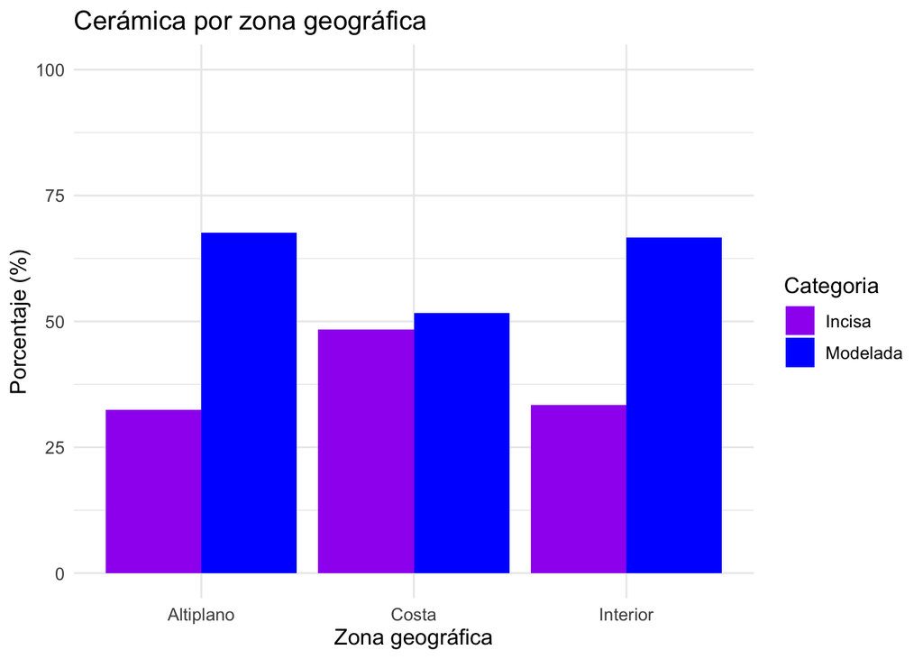

```r
ggplot(data = data2, aes(x = Sitio, y = Porcentaje, fill = Categoria)) +
  geom_bar(stat = "identity", position = position_dodge()) +
  scale_y_continuous(limits = c(0, 100)) +
  scale_fill_manual(values = c("purple", "blue")) +
  labs(x = "Zona geográfica", y = "Porcentaje (%)", title = "Cerámica por zona geográfica") +
  theme_minimal() +
  theme(text = element_text(size = 12))
```

#### **6. Boxplot de diámetro de borde cerámico por zona.**

Usando la base de datos `Diametro ceramica.xlsx`, podemos comparar la distribución del diámetro del borde de la cerámica incisa entre las distintas zonas geográficas con un boxplot.

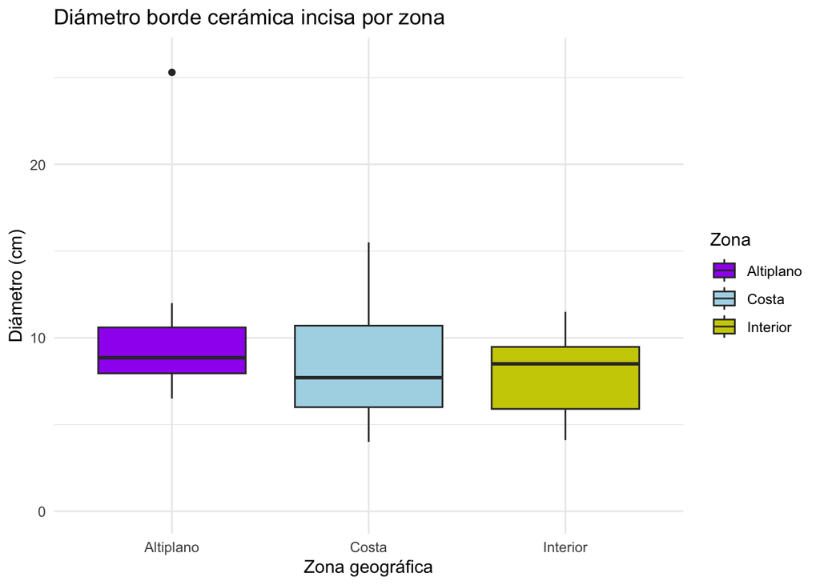

```r
ggplot(data = diametro_ceramica, aes(x = Zona, y = Diametro, fill = Zona)) +
  geom_boxplot() +
  scale_fill_manual(values = c("purple", "lightblue", "yellow3")) +
  scale_y_continuous(limits = c(0, 26)) +
  labs(x = "Zona geográfica", y = "Diámetro (cm)", title = "Diámetro borde cerámica incisa por zona") +
  theme_minimal()
```

#### **7. Trabajo en Clases 4.**

Para esta actividad trabajaremos con las bases de datos `Liticos.xlsx` y `Largo liticos.xlsx`. Puedes encontrarlas en el repositorio del curso.

1. Crea un nuevo `data.frame` a partir de la base de datos `Liticos` y calcula los porcentajes de columna para cada zona geográfica.
2. Crea un nuevo `data.frame` que incluya las columnas `Sitio`, `Categoria` y `Porcentaje`, siguiendo el mismo procedimiento que usamos con la cerámica.
3. Realiza un gráfico de barras usando los datos del nuevo `data.frame`. ¿Qué tipo de punta es más frecuente en el altiplano, costa e interior, respectivamente? ¿Existen diferencias entre zonas? Si fuese así, ¿a qué crees que se deben?
4. Realiza un boxplot con la base de datos `Largo liticos` para comparar cómo se distribuyen los largos de las puntas de obsidiana por zona geográfica. ¿Dónde hay puntas más largas? ¿Dónde hay puntas más pequeñas? ¿Las distribuciones son simétricas o dispersas? ¿Dónde tienden a agruparse los datos en cada boxplot?

← Clase Anterior Índice Siguiente Clase →